# Phylogenetic Independent Contrasts

July/2015

In this tutorial we will learn to apply the independent contrasts method of Felsenstein (1985) for estimating the evolutionary correlation between characters.

Felsenstein (1985) identified (and, to a large extent, solved) a problem that had previously recognized, but that was underappreciated: and that is, that the data for species cannot be treated as independent data points from the point of view of statistical analysis.

To learn the contrasts method, we’ll first need to learn some basics in linear model fitting in the R language.

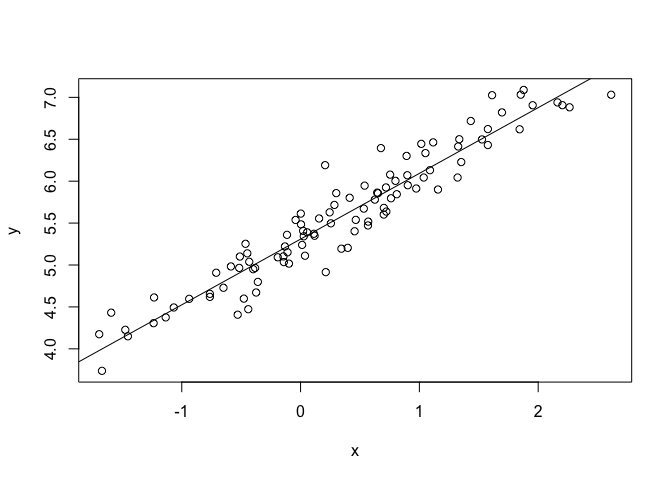

```r
## linear regression model is y = b0 + b*x + e
b0<-5.3
b<-0.75
x<-rnorm(n=100,sd=1)
y<-b0+b*x+rnorm(n=100,sd=0.2)
plot(x,y)
fit<-lm(y~x)
abline(fit)
```

```r
fit
```

```
##
## Call:
## lm(formula = y ~ x)
##
## Coefficients:
## (Intercept)            x
##      5.3092       0.7843
```

```r
summary(fit)
```

```
##
## Call:
## lm(formula = y ~ x)
##
## Residuals:
##      Min       1Q   Median       3Q      Max
## -0.56077 -0.13564 -0.01578  0.15881  0.71987
##
## Coefficients:
##             Estimate Std. Error t value Pr(>|t|)
## (Intercept)  5.30916    0.02427  218.78   <2e-16 ***
## x            0.78426    0.02421   32.39   <2e-16 ***
## ---
## Signif. codes:  0 '***' 0.001 '**' 0.01 '*' 0.05 '.' 0.1 ' ' 1
##
## Residual standard error: 0.2289 on 98 degrees of freedom
## Multiple R-squared:  0.9146, Adjusted R-squared:  0.9137
## F-statistic:  1049 on 1 and 98 DF,  p-value: < 2.2e-16
```

```r
anova(fit)
```

```
## Analysis of Variance Table
##
## Response: y
##           Df Sum Sq Mean Sq F value    Pr(>F)
## x          1 54.984  54.984  1049.4 < 2.2e-16 ***
## Residuals 98  5.135   0.052
## ---
## Signif. codes:  0 '***' 0.001 '**' 0.01 '*' 0.05 '.' 0.1 ' ' 1
```

```r
## fit is an object of class "lm"
class(fit)
```

```
## [1] "lm"
```

```r
## coefficients of the fitted model
fit$coefficients
```

```
## (Intercept)           x
##    5.309157    0.784256
```

```r
## p-value of the fitted model
anova(fit)[["Pr(>F)"]][1]
```

```
## [1] 3.70078e-54
```

We can see that when the residual error in y given x are normal & independent, hypothesis tests about our fitted model using ANOVA are unbiased & have the correct type I error rate:

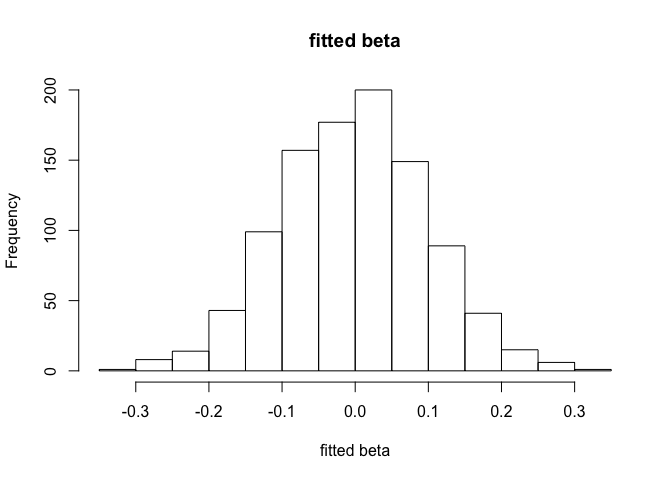

```r
foo<-function(){
        x<-rnorm(n=100)
        y<-rnorm(n=100)
        fit<-lm(y~x)
        setNames(c(fit$coefficients[2],anova(fit)[["Pr(>F)"]][1]),c("beta","p"))
}
X<-t(replicate(1000,foo()))
hist(X[,1],xlab="fitted beta",main="fitted beta")
```

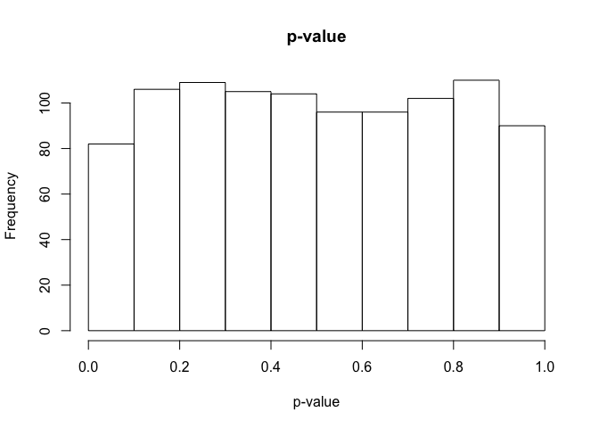

```r
hist(X[,2],xlab="p-value",main="p-value")
```

```r
## expected value is the nominal type I error rate, 0.05
mean(X[,2]<=0.05)
```

```
## [1] 0.046
```

This simulation shows very simply that when standard statistical assumptions are satisfied, our parameter estimates are unbiased and type I error is at or around the nominal level.

The difficulty with phylogenetic data is that the observations for y are no longer independent & identically distributed. Let’s consider one case:

```r
## load phytools
library(phytools)
```

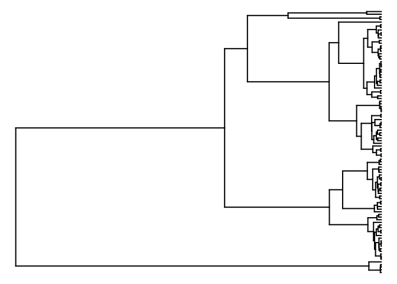

```r
## simulate a coalescent shaped tree
tree<-rcoal(n=100)
plotTree(tree,ftype="off")
```

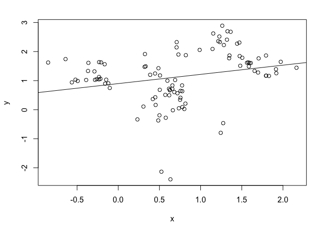

```r
## simulate uncorrelated Brownian evolution
x<-fastBM(tree)
y<-fastBM(tree)
par(mar=c(5.1,4.1,2.1,2.1))
plot(x,y)
fit<-lm(y~x)
abline(fit)
```

```r
fit
```

```
##
## Call:
## lm(formula = y ~ x)
##
## Coefficients:
## (Intercept)            x
##      0.8982       0.3173
```

```r
summary(fit)
```

```
##
## Call:
## lm(formula = y ~ x)
##
## Residuals:
##     Min      1Q  Median      3Q     Max
## -3.4958 -0.4442  0.1802  0.5412  1.5909
##
## Coefficients:
##             Estimate Std. Error t value Pr(>|t|)
## (Intercept)   0.8982     0.1286   6.986 3.44e-10 ***
## x             0.3173     0.1263   2.512   0.0136 *
## ---
## Signif. codes:  0 '***' 0.001 '**' 0.01 '*' 0.05 '.' 0.1 ' ' 1
##
## Residual standard error: 0.8965 on 98 degrees of freedom
## Multiple R-squared:  0.06052,    Adjusted R-squared:  0.05093
## F-statistic: 6.313 on 1 and 98 DF,  p-value: 0.01362
```

```r
anova(fit)
```

```
## Analysis of Variance Table
##
## Response: y
##           Df Sum Sq Mean Sq F value  Pr(>F)
## x          1  5.074  5.0737  6.3125 0.01362 *
## Residuals 98 78.767  0.8037
## ---
## Signif. codes:  0 '***' 0.001 '**' 0.01 '*' 0.05 '.' 0.1 ' ' 1
```

We can see from this example, that it is not difficult for phylogeny to induce a type I error.

Here it is because clusters of closely related taxa have highly similar phenotypes. In other words, they are not independent data points about the evolutionary process for x and y on the tree:

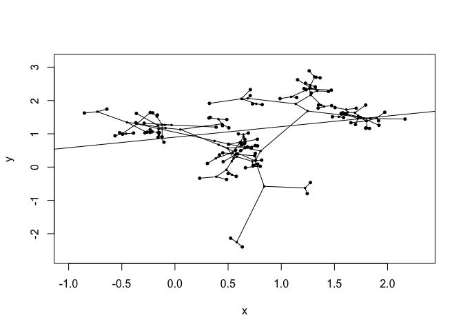

```r
## this is a projection of the tree into morphospace
phylomorphospace(tree,cbind(x,y),label="off",node.size=c(0.5,0.7))
abline(fit)
```

Felsenstein’s (1985) algorithm substitutes the contrasts between species (& nodes) for the original values. Let’s see if it resolves our type I error in this case:

```r
ix<-pic(x,tree)
iy<-pic(y,tree)
fit<-lm(iy~ix-1) ## we have to fit the model without an intercept term
fit
```

```
##
## Call:
## lm(formula = iy ~ ix - 1)
##
## Coefficients:
##       ix
## -0.02926
```

```r
fit
```

```
##
## Call:
## lm(formula = iy ~ ix - 1)
##
## Coefficients:
##       ix
## -0.02926
```

```r
anova(fit)
```

```
## Analysis of Variance Table
##
## Response: iy
##           Df  Sum Sq Mean Sq F value Pr(>F)
## ix         1   0.068 0.06787  0.0632  0.802
## Residuals 98 105.211 1.07358
```

Investigators sometimes get the naive impression that the contrasts algorithm ‘weakens’ the power of their statistical analysis. What we’re seeing here is actually a spurious result being re-identified as such - not a loss of power.

Finally, IC is unbiased when we do have an effect:

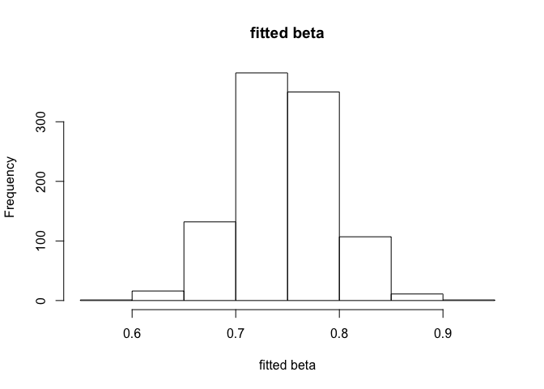

```r
foo<-function(beta,tree){
        tree<-pbtree(n=100,scale=1)
        x<-fastBM(tree)
        y<-beta*x+fastBM(tree,sig2=0.2)
        ix<-pic(x,tree)
        iy<-pic(y,tree)
        fit<-lm(iy~ix-1)
        fit$coefficients[1]
}
bhat<-replicate(1000,foo(0.75,tree))
hist(bhat,xlab="fitted beta",main="fitted beta")
```

## Work on your own:

Do as much as you can of the following exercise on your own. We are here to help!

1. Show that OLS for data simulated on the tree results in elevated type I error. How is the type I error rate affected by tree shape. (Hint, use pbtree(…,d=0), pbtree(…,d>0), and rcoal.)
2. Show that phylogenetic independent contrasts results in the correct type I error.
3. Show that OLS is unbiased.